# Week 8 Lab. ANOVA

Craig Enders

Friday November 20

■ data frame name ■ numeric variable ■ categorical variable (factor) ■ raw data file name

# The Data

People of color in the United States disproportionately experience trauma and posttraumatic stress disorder (PTSD). Pregnant women of color may be at particular risk because perinatal PTSD is associated with adverse maternal and child health outcomes. Because PTSD comprises distinct symptom dimensions, researchers may need to examine more than overall symptom severity. These data are from a study of 1,663 Latina, Black, and non-Hispanic White postpartum women in the United States that examined racial and ethnic differences across multiple dimensions of PTSD symptoms.

You have seen these data before in the data blitz exercises. This lab asks whether anxious arousal symptoms (`AnxiousArousal`) differ across the three racial and ethnic groups (`Race`). The independent-samples *t*-test from last week compares two groups; the one-way analysis of variance (ANOVA) extends that comparison to three or more.

| Variable | Description | Scale |
| --- | --- | --- |
| `Participant` | Individual identifier | Integer index |
| `Age` | Age in years | 15 to 43 |
| `Nativity` | Country of birth | 0 = US born, 1 = Foreign born |
| `Race` | Racial/ethnic identity | 0 = Black, 1 = Latina, 2 = White |
| `Education` | Highest education | 0 = Less than high school, 1 = High school, 2 = Some college, 3 = BA or higher |
| `Poverty` | Household poverty status | 0 = Above poverty line, 1 = Below poverty line |
| `Reexperiencing` | PTSD re-experiencing symptom score | 3 to 25 |
| `Avoidance` | PTSD avoidance symptom score | 0 to 11 |
| `DysphoricArousal` | PTSD dysphoric arousal symptom score | 1 to 16 |
| `Numbing` | PTSD emotional numbing symptom score | 4 to 23 |
| `AnxiousArousal` | PTSD anxious arousal (hyperarousal) symptom score | 1 to 11 |

Higher scores on `AnxiousArousal` indicate more severe symptoms. The categorical variable `Race` is entered as 0, 1, and 2, not as labels; a later step uses the `factor()` function to attach those labels to the data.

# Preliminaries: Loading Packages

R’s built-in functions handle basic statistics, but some tools in this lab come from add-on packages. `library()` makes a package’s functions available for the current session; it has to be run each time you open R, and it assumes the package was installed beforehand (see the Week 0 R Package Installation Script).

Two packages appear for the first time this week. The performance package provides `r2()`, which computes the ANOVA effect size, and the rstatix package provides `cohens_d()`, which computes standardized mean differences for every pair of groups at once. Both are in the Week 0 installation script.

```r
# ggplot2 draws the graphs
library(ggplot2)

# performance provides r2() for the proportion of variance explained
library(performance)

# psych provides describe() and describeBy()
library(psych)

# rstatix provides cohens_d() for pairwise effect sizes
library(rstatix)

# summarytools provides dfSummary() for data summaries
library(summarytools)

# rstudioapi talks to RStudio, used here to find the folder that contains this script
library(rstudioapi)
```

# Importing Data

There are two ways to get the data file into R. The document uses the first; the second is shown for reference because it is the one you will use with data files stored on your own computer.

Both methods call `read.csv()` with `stringsAsFactors = TRUE`, the same call used in the assignments. The argument converts any text column to a factor, but this file has none: the categorical variables are stored as numeric codes, so every column is read as numeric. The next section converts `Race` to a factor by hand.

## Option 1: Read From the Course Website

The data file lives on the course GitHub site. Store the web address in an object, then hand that address to `read.csv()`.

```r
# store the web address of the raw data file
filepath <- "https://raw.githubusercontent.com/craigenders/psych250a/main/data/PTSD.csv"

# read the file at that address into a data frame named PTSD
PTSD <- read.csv(filepath, stringsAsFactors = TRUE)
```

## Option 2: Read From the Folder That Contains the Script

When a data file is saved in the same folder as your R script, you can point R at that folder and then refer to the file by name alone. The rstudioapi package asks RStudio for the path of the script you are currently editing; `dirname()` strips the file name to leave the folder, and `setwd()` makes that folder R’s working directory. `getwd()` prints the working directory so you can confirm it landed where you expected. After that, `read.csv()` needs only the file name.

This block is displayed but not run, because a knitted document has no script to locate. Run it from an R script saved next to `PTSD.csv`. In the lab script the same lines are commented out; remove the leading `#` to use them.

```r
# set the working directory to the folder that contains this script
setwd(dirname(getActiveDocumentContext()$path))

# print the working directory to confirm the location
getwd()

# read PTSD.csv from the working directory into a data frame named PTSD
PTSD <- read.csv("PTSD.csv", stringsAsFactors = TRUE)
```

# Converting Categorical Variables to Factors

R does not know that `Race` is categorical; it sees a numeric column of 0s, 1s, and 2s. Left that way, `aov()` would treat `Race` as a single numeric predictor rather than as three groups, and the Tukey comparisons below would not run. The `factor()` function converts the column to a factor, R’s term for a categorical variable. The `levels` argument lists the codes in the data, and the `labels` argument gives each code a name; the two are matched in order, so 0 becomes Black, 1 becomes Latina, and 2 becomes White.

The order of the levels carries through the rest of the lab: it sets the order of the groups in the descriptive statistics and on the graph’s horizontal axis, and it determines the direction of subtraction in the pairwise comparisons.

Run this block only once after reading the data. Once a column is a factor, re-running `factor()` on it with the same `levels` produces all `NA` values, because the numeric codes no longer exist.

```r
# convert Race from 0/1/2 codes to a factor with descriptive labels
PTSD$Race <- factor(PTSD$Race,
                    levels = c(0, 1, 2),
                    labels = c("Black", "Latina", "White"))

# print the first few rows to confirm the labels replaced the codes
head(PTSD)
```

```
  Participant Age Nativity  Race Education Poverty Reexperiencing Avoidance DysphoricArousal
1           1  19        0 Black         1       0             13         3                4
2           2  25        1 Black         0       1              9         2                4
3           3  24        0 Black         1       1             12         4                3
4           4  37        0 Black         2       0              6         3                4
5           5  28        0 Black         2       0             16         2               11
6           6  30        0 Black         2       0             10         4                3
  Numbing AnxiousArousal
1       6              4
2       6              4
3       7              6
4       8              1
5       7              7
6       5              5
```

# Summarizing Data

`dfSummary()` from the summarytools package produces one row per variable showing its type, a compact summary of its values, a small graph of its distribution, and the number of valid and missing cases. The data frame has eleven variables, but this lab uses two, so the square brackets select just those columns: `PTSD[, c("Race", "AnxiousArousal")]` keeps every row (the empty space before the comma) and the two named columns. In the HTML version of this lab, the table is handed to `print()` with `method = "render"` so that it displays as formatted HTML; that wrapper is not needed in your own documents.

```r
# overview of the two variables used in this lab
print(dfSummary(PTSD[, c("Race", "AnxiousArousal")]), method = "render")
```

Data Frame Summary

PTSD

**Dimensions**: 1663 x 2  
**Duplicates**: 1633

| **No** | **Variable** | **Stats / Values** | **Freqs (% of Valid)** | **Graph** | **Valid** | **Missing** |
| --- | --- | --- | --- | --- | --- | --- |
| 1 | Race [factor] | 1. Black 2. Latina 3. White | 901 ( 54.2% ) 373 ( 22.4% ) 389 ( 23.4% ) |  | 1663 (100.0%) | 0 (0.0%) |
| 2 | AnxiousArousal [integer] | Mean (sd) : 3.4 (1.8) min ≤ med ≤ max: 1 ≤ 3 ≤ 11 IQR (CV) : 2 (0.5) | 11 distinct values |  | 1663 (100.0%) | 0 (0.0%) |

Generated by summarytools 1.1.5 ([R](https://www.r-project.org/) version 4.6.1)  
2026-11-24

The sample includes 901 Black, 373 Latina, and 389 White women, and neither variable has missing data. Anxious arousal scores pile up at the low end of the 1 to 11 scale.

# Descriptive Statistics by Group

An ANOVA compares group means, so the first step is to look at each group’s descriptive statistics. `describeBy()` from the psych package accepts the same outcome-by-group formula that the analysis functions use below, outcome on the left of the tilde and grouping variable on the right, and produces a separate table of descriptive statistics for each group.

```r
# descriptive statistics for the outcome separately for each group (psych package)
describeBy(AnxiousArousal ~ Race, data = PTSD)
```

```
 Descriptive statistics by group
Race: Black
               vars   n mean   sd median trimmed  mad min max range skew kurtosis   se
AnxiousArousal    1 901 3.43 1.96      3    3.19 1.48   1  11    10 1.14     0.88 0.07
---------------------------------------------------------------------------
Race: Latina
               vars   n mean   sd median trimmed  mad min max range skew kurtosis   se
AnxiousArousal    1 373 3.49 1.61      3    3.32 1.48   1  10     9 0.88     0.47 0.08
---------------------------------------------------------------------------
Race: White
               vars   n mean   sd median trimmed  mad min max range skew kurtosis   se
AnxiousArousal    1 389 3.07 1.56      3    2.85 1.48   1  10     9 1.44     2.56 0.08
```

Mean anxious arousal is 3.43 (*SD* = 1.96) for the 901 Black women, 3.49 (*SD* = 1.61) for the 373 Latina women, and 3.07 (*SD* = 1.56) for the 389 White women. The Black and Latina means are close, and the White mean is about 0.4 points lower than both. The standard deviations are not identical; the Black group’s is noticeably larger, which matters for the sensitivity check later in the lab.

# Graphing Group Means and Confidence Intervals

A graph of the three means with their 95% confidence intervals shows the pattern before any test is run. Every ggplot2 graph is built in layers joined by `+`:

- `ggplot(data = PTSD, aes(x = Race, y = AnxiousArousal, group = 1))` names the data frame and maps the grouping variable to the horizontal axis and the outcome to the vertical axis. `group = 1` tells ggplot2 to treat the three groups as one series so that a line can connect their means; without it, each group is its own series and no line is drawn.
- `stat_summary(fun = mean, geom = "line")` computes each group’s mean and connects the means with a line.
- `stat_summary(fun = mean, geom = "point", size = 3)` draws a dot at each mean.
- `stat_summary(fun.data = mean_cl_normal, geom = "pointrange")` computes the mean and its 95% confidence limits and draws a vertical line spanning the interval, as in the Week 4 lab.

Changing the outcome or the grouping variable requires editing only the two names inside `aes()`; the rest of the call stays the same.

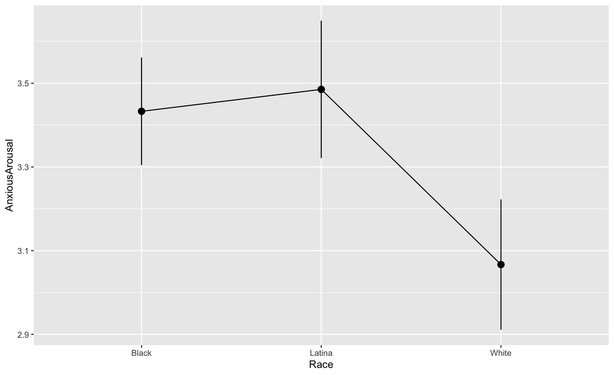

```r
# means and 95% confidence interval error bars by group (ggplot2 package)
ggplot(data = PTSD, aes(x = Race, y = AnxiousArousal, group = 1)) +
  stat_summary(fun = mean, geom = "line") +
  stat_summary(fun = mean, geom = "point", size = 3) +
  stat_summary(fun.data = mean_cl_normal, geom = "pointrange")
```

The Black and Latina intervals overlap almost entirely, and the White interval sits below both with little or no overlap. The line connecting the means is a visual aid only; the horizontal axis is categorical, and nothing is being measured between the groups.

# One-Way ANOVA

`aov()` fits the analysis of variance model from the same outcome-by-group formula. The fitted model is stored in an object named `anovaresults`, and `summary()` prints the ANOVA table. Storing the model matters because the effect size and Tukey functions below take the stored object as input rather than refitting the model.

```r
# anova table with classic F statistic (base R)
anovaresults <- aov(AnxiousArousal ~ Race, data = PTSD)
summary(anovaresults)
```

```
              Df Sum Sq Mean Sq F value  Pr(>F)
Race           2     44  22.032   6.797 0.00115 **
Residuals   1660   5381   3.241
---
Signif. codes:  0 '***' 0.001 '**' 0.01 '*' 0.05 '.' 0.1 ' ' 1
```

The table has one row for the grouping variable and one for the residuals. `Df` gives the degrees of freedom, 2 for three groups and 1660 for the residuals (*N* − 3). `Sum Sq` and `Mean Sq` are the sums of squares and mean squares (sum of squares divided by *df*) for between-group and within-group variation. `F value` is the ratio of the two mean squares, and `Pr(>F)` is its *p*-value. Here *F*(2, 1660) = 6.80, *p* = .001, so the three population means are not all equal. The test does not say which groups differ; that is the job of the pairwise comparisons below.

# Sensitivity Check: Welch’s F Test

The classic *F* test assumes that the groups have identical variation in the population (homogeneity of variance). `oneway.test()` computes Welch’s *F*, which allows each group its own variance, in the same way that Welch’s *t*-test did last week. The function takes the formula and data frame directly rather than the stored model, and by default it does not assume equal variances.

```r
# welch's F statistic for heterogeneous variation (base R)
oneway.test(AnxiousArousal ~ Race, data = PTSD)
```

```
    One-way analysis of means (not assuming equal variances)

data:  AnxiousArousal and Race
F = 8.4651, num df = 2.00, denom df = 868.45, p-value = 0.0002286
```

Welch’s *F*(2, 868.45) = 8.47, *p* < .001. The denominator *df* is no longer *N* − 3, because the adjustment for unequal variances reduces it. The conclusion matches the classic test, so the group differences do not hinge on the equal-variance assumption even though the standard deviations differ.

# R-Squared Effect Size

The ANOVA *F* statistic grows with the sample size, so it does not describe how large the group differences are. *R*² is the proportion of variance in the outcome that is explained by group membership: the between-group sum of squares divided by the total sum of squares. `r2()` from the performance package computes it from the stored model and also reports an adjusted version that corrects for the number of groups.

```r
# r-square effect size (performance package)
r2(anovaresults)
```

```
# R2 for Anova Regression
       R2: 0.008
  adj. R2: 0.007
```

Group membership explains about 0.8% of the variance in anxious arousal (*R*² = .008). The differences are statistically reliable because the sample is large, but they are small.

# Pairwise Comparisons: Tukey Tests

A significant *F* says that at least one pair of means differs. `TukeyHSD()` tests every pair of groups while holding the family-wise Type I error rate at .05 across the whole set of comparisons, so the three tests together have a 5% false-positive rate rather than 5% each. It takes the stored `aov()` model as input.

```r
# pairwise Tukey mean comparisons (base R)
TukeyHSD(anovaresults)
```

```
  Tukey multiple comparisons of means
    95% family-wise confidence level

Fit: aov(formula = AnxiousArousal ~ Race, data = PTSD)

$Race
                    diff        lwr        upr     p adj
Latina-Black  0.05240231 -0.2076272  0.3124318 0.8841360
White-Black  -0.36601434 -0.6222339 -0.1097947 0.0023719
White-Latina -0.41841665 -0.7244741 -0.1123592 0.0039054
```

Each row is one comparison, named second group minus first group. `diff` is the mean difference, `lwr` and `upr` are the limits of the 95% confidence interval adjusted for multiple comparisons, and `p adj` is the adjusted *p*-value. Latina and Black women do not differ (difference = 0.05, *p* = .88). White women score lower than both Black women (difference = −0.37, *p* = .002) and Latina women (difference = −0.42, *p* = .004). The significant *F* traces to the White group.

# Pairwise Standardized Mean Difference Effect Sizes

`cohens_d()` from the rstatix package computes the standardized mean difference (the mean difference divided by the pooled standard deviation) for every pair of groups from the outcome-by-group formula. Last week’s `cohen.d()` from the psych package handles only two groups; this function is the multi-group counterpart.

```r
# standardized mean difference effect size for all comparisons (rstatix package)
cohens_d(AnxiousArousal ~ Race, data = PTSD)
```

```
# A tibble: 3 × 7
  .y.            group1 group2 effsize    n1    n2 magnitude
* <chr>          <chr>  <chr>    <dbl> <int> <int> <ord>
1 AnxiousArousal Black  Latina -0.0292   901   373 negligible
2 AnxiousArousal Black  White   0.206    901   389 small
3 AnxiousArousal Latina White   0.264    373   389 small
```

Each row names the two groups (`group1` minus `group2`), the effect size (`effsize`), the sample sizes, and a verbal label based on Cohen’s benchmarks. The Black–Latina difference is negligible (*d* = −0.03), and the two comparisons involving the White group are small (*d* ≈ 0.20 and 0.26). Check the sign of each value against the group means, because the direction of the subtraction depends on how the function orders the groups.